# Beers and Breweries EDA

Mohammad Merajmohammadi and Trevor Kunz

2023-10-06

```r
# Load libraries
library(tidyverse)
library(gridExtra)
```

```r
library(ggplot2)
library(plotly)
library(stats)
library(caret)
library(e1071)
library(class)
```

## 1.

How many breweries are present in each state? Answer: Please refer to the graph below on the answer to this question. We can see the top 3 states with the most breweries is Colorado (47), California (39) and Michigan (32).

```r
beers = read.csv("https://github.com/EymanMeraj/DDS6306_Project1/raw/main/Beers.csv", header = TRUE, stringsAsFactors =  TRUE)
breweries = read.csv("https://github.com/EymanMeraj/DDS6306_Project1/raw/main/Breweries.csv", header = TRUE, stringsAsFactors = TRUE)


# Group data by state
breweries_by_state <- breweries %>%
  group_by(State) %>%
  summarize(Count = n()) %>% # count how many breweries are present in each state
  arrange(desc(Count)) # Sort the grouped data by Count

breweries_by_state
```

```
## # A tibble: 51 × 2
##    State Count
##    <fct> <int>
##  1 " CO"    47
##  2 " CA"    39
##  3 " MI"    32
##  4 " OR"    29
##  5 " TX"    28
##  6 " PA"    25
##  7 " MA"    23
##  8 " WA"    23
##  9 " IN"    22
## 10 " WI"    20
## # ℹ 41 more rows
```

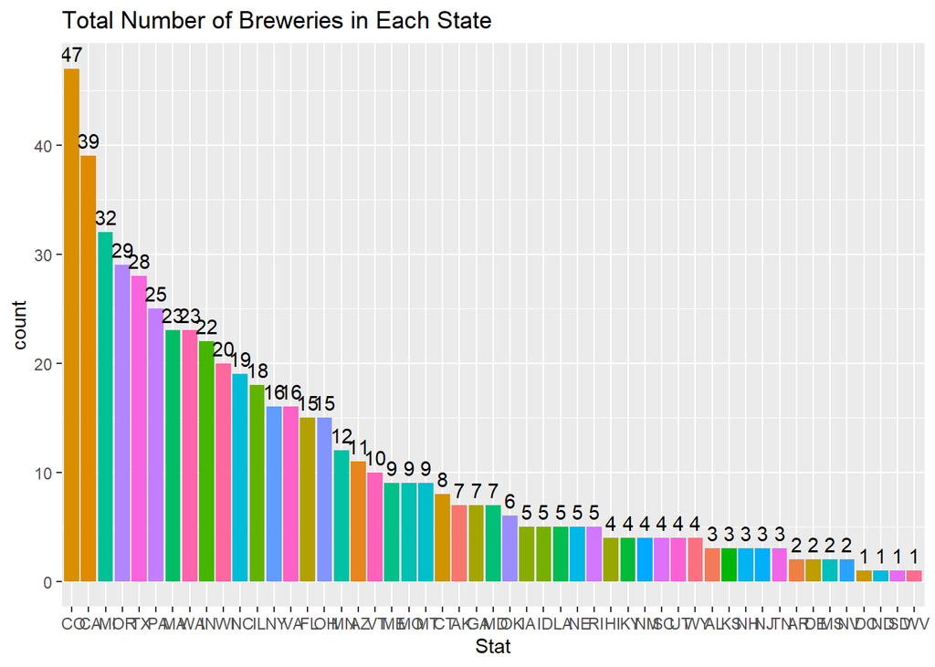

```r
#breweries %>% ggplot(aes(x = State, fill = State)) + geom_bar() + ggtitle("Count of Breweries in Each State") + ylab("Count of Breweries") + ggthemes::theme_economist() + guides(fill = FALSE)

#Create a bar plot to show the total number of breweries in each state
breweries %>%
  select(State)%>%
  ggplot(aes(x=reorder(State,State,function(x)-length(x)), fill = State))+
  geom_bar()+
  ggtitle("Total Number of Breweries in Each State")+
  xlab("Stat")+
  geom_text(stat='count', aes(label=..count..), vjust=-0.5) +
  guides(fill = FALSE)
```

## 2.

Merge beer data with the breweries data. Print the first 6 observations and the last six observations to check the merged file. (RMD only, this does not need to be included in the presentation or the deck.)

```r
beers = beers %>% rename(BeerName = Name, Brew_ID = Brewery_id)
breweries = breweries %>% rename(BreweryName = Name)

# Merge
beers_breweries = left_join(beers, breweries, by = "Brew_ID")

# First 6 obs
head(beers_breweries, 6)
```

```
##              BeerName Beer_ID   ABV IBU Brew_ID                          Style
## 1            Pub Beer    1436 0.050  NA     409            American Pale Lager
## 2         Devil's Cup    2265 0.066  NA     178        American Pale Ale (APA)
## 3 Rise of the Phoenix    2264 0.071  NA     178                   American IPA
## 4            Sinister    2263 0.090  NA     178 American Double / Imperial IPA
## 5       Sex and Candy    2262 0.075  NA     178                   American IPA
## 6        Black Exodus    2261 0.077  NA     178                  Oatmeal Stout
##   Ounces               BreweryName City State
## 1     12 10 Barrel Brewing Company Bend    OR
## 2     12       18th Street Brewery Gary    IN
## 3     12       18th Street Brewery Gary    IN
## 4     12       18th Street Brewery Gary    IN
## 5     12       18th Street Brewery Gary    IN
## 6     12       18th Street Brewery Gary    IN
```

```r
# Last 6 obs
tail(beers_breweries, 6)
```

```
##                         BeerName Beer_ID   ABV IBU Brew_ID
## 2405 Rocky Mountain Oyster Stout    1035 0.075  NA     425
## 2406                   Belgorado     928 0.067  45     425
## 2407               Rail Yard Ale     807 0.052  NA     425
## 2408             B3K Black Lager     620 0.055  NA     425
## 2409         Silverback Pale Ale     145 0.055  40     425
## 2410        Rail Yard Ale (2009)      84 0.052  NA     425
##                         Style Ounces             BreweryName   City State
## 2405           American Stout     12 Wynkoop Brewing Company Denver    CO
## 2406              Belgian IPA     12 Wynkoop Brewing Company Denver    CO
## 2407 American Amber / Red Ale     12 Wynkoop Brewing Company Denver    CO
## 2408              Schwarzbier     12 Wynkoop Brewing Company Denver    CO
## 2409  American Pale Ale (APA)     12 Wynkoop Brewing Company Denver    CO
## 2410 American Amber / Red Ale     12 Wynkoop Brewing Company Denver    CO
```

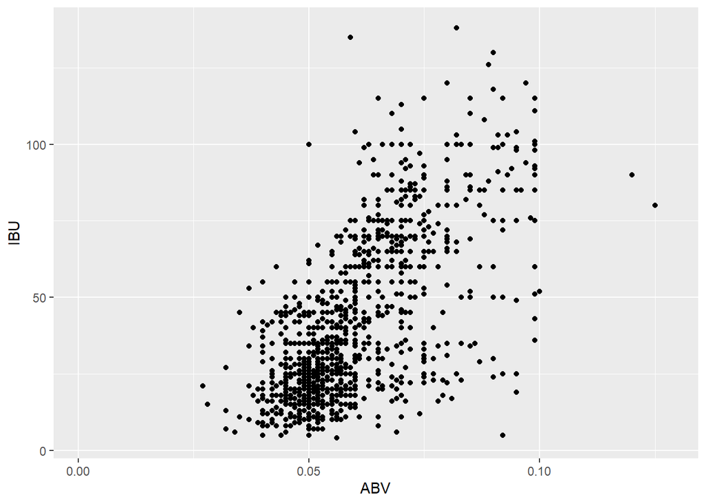

```r
beers_breweries %>% ggplot(aes(x = ABV, y = IBU))+ geom_point()
```

## 3.

Address the missing values in each column answer: We can see that there are 62 missing values in ABV and 1005 missing values in IBU Data is missing completely at random Missing data was imputed for IBU with Linear Regression as we found a linear relationship between ABV and IBU Missing Data for ABV was missing IBU as well and represented 2.57% of the data, therefore it was removed

```r
# Check missing values in each column
missing_values <- sapply(beers_breweries, function(x) sum(is.na(x)))

#Set variable for the missing data
missing_data = beers_breweries[is.na(beers_breweries$IBU), ]

# Impute data with Linear Regression
model = lm(IBU ~ ABV, data = beers_breweries)


# Setting variables for intercepts and coefficient for ABV
intercept = coef(model)["(Intercept)"]
coef_abv = coef(model)["ABV"]

# Calculate estimated IBU for missing data
missing_data$Estimated_IBU = ifelse((intercept + coef_abv * missing_data$ABV) < 0, 0, round(intercept + coef_abv * missing_data$ABV))



#calculating the values that are missing ABV and IBU data
missing_abv = beers_breweries[is.na(beers_breweries$ABV),]
nrow(missing_abv)/nrow(beers_breweries)
```

```
## [1] 0.02572614
```

```r
#we have 2.57% of data missing both, data is MCAR, throwing out

#Filling in the missing IBU data from the estimated values.
beers_breweries$IBU[is.na(beers_breweries$IBU)] = missing_data$Estimated_IBU[is.na(missing_data$IBU)]

#removing the missing ABV and IBU data as it is 2.57% of data and should cause minimal impact to the analysis
beers_breweries = beers_breweries %>% filter(!is.na(beers_breweries$ABV))

#print the summary and dataset
summary(beers_breweries)
```

```
##                    BeerName       Beer_ID            ABV
##  Nonstop Hef Hop       :  12   Min.   :   1.0   Min.   :0.00100
##  Dale's Pale Ale       :   6   1st Qu.: 827.8   1st Qu.:0.05000
##  Oktoberfest           :   6   Median :1463.5   Median :0.05600
##  Longboard Island Lager:   4   Mean   :1439.4   Mean   :0.05977
##  1327 Pod's ESB        :   3   3rd Qu.:2078.2   3rd Qu.:0.06700
##  Boston Lager          :   3   Max.   :2692.0   Max.   :0.12800
##  (Other)               :2314
##       IBU            Brew_ID                                 Style
##  Min.   :  0.00   Min.   :  1.0   American IPA                  : 417
##  1st Qu.: 25.00   1st Qu.: 94.0   American Pale Ale (APA)       : 239
##  Median : 36.00   Median :206.0   American Amber / Red Ale      : 125
##  Mean   : 42.54   Mean   :231.3   American Blonde Ale           : 104
##  3rd Qu.: 56.00   3rd Qu.:366.0   American Double / Imperial IPA: 103
##  Max.   :138.00   Max.   :558.0   American Pale Wheat Ale       :  95
##                                   (Other)                       :1265
##      Ounces                          BreweryName             City
##  Min.   : 8.40   Brewery Vivant            :  60   Grand Rapids:  64
##  1st Qu.:12.00   Oskar Blues Brewery       :  42   Portland    :  64
##  Median :12.00   Sun King Brewing Company  :  36   Chicago     :  55
##  Mean   :13.59   Cigar City Brewing Company:  25   San Diego   :  42
##  3rd Qu.:16.00   Sixpoint Craft Ales       :  24   Boulder     :  41
##  Max.   :32.00   Hopworks Urban Brewery    :  23   Indianapolis:  41
##                  (Other)                   :2138   (Other)     :2041
##      State
##   CO    : 250
##   CA    : 182
##   MI    : 151
##   IN    : 137
##   OR    : 125
##   TX    : 124
##  (Other):1379
```

```r
beers_breweries
```

[output not shown]

[output cut: 7032 more lines]

## 4.

```r
#Compute Median of ABV by State
beers_breweries %>%
  filter(!is.na(ABV))%>%
  group_by(State)%>%
  summarize(MedianABV = median(ABV))%>%
  arrange(desc(MedianABV))%>%
  print(n=50)
```

```
## # A tibble: 51 × 2
##    State MedianABV
##    <fct>     <dbl>
##  1 " DC"    0.0625
##  2 " KY"    0.0625
##  3 " MI"    0.062
##  4 " NM"    0.062
##  5 " WV"    0.062
##  6 " CO"    0.0605
##  7 " AL"    0.06
##  8 " CT"    0.06
##  9 " NV"    0.06
## 10 " OK"    0.06
## 11 " SD"    0.06
## 12 " CA"    0.058
```

[output cut: 39 more lines]

```r
#Compute Median of IBU by State
beers_breweries %>%
  filter(!is.na(IBU))%>%
  group_by(State)%>%
  summarize(MedianIBU = median(IBU))%>%
  arrange(desc(MedianIBU))%>%
  print(n=50)
```

```
## # A tibble: 51 × 2
##    State MedianIBU
##    <fct>     <dbl>
##  1 " WV"      57.5
##  2 " DE"      52
##  3 " DC"      49.5
##  4 " NV"      46
##  5 " MI"      45
##  6 " MS"      45
##  7 " NM"      45
##  8 " AL"      43
##  9 " MN"      43
## 10 " SD"      43
## 11 " VA"      41
## 12 " AK"      40
```

[output cut: 39 more lines]

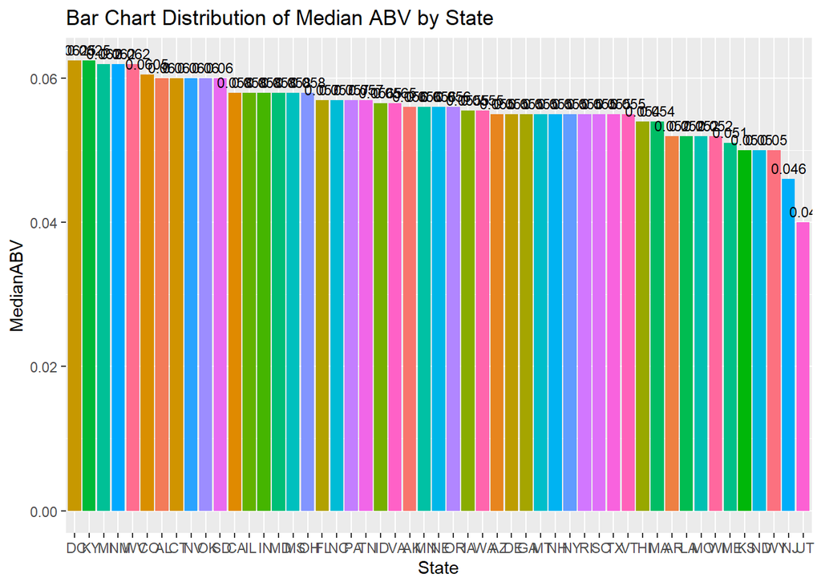

```r
#Create bar chart of median ABV for each State
beers_breweries %>%
  filter(!is.na(ABV))%>%
  group_by(State)%>%
  summarize(MedianABV = median(ABV))%>%
  ggplot(aes(x=reorder(State,-MedianABV), y = MedianABV, fill=State))+
  geom_bar(stat="identity")+
  xlab("State")+
  ggtitle("Bar Chart Distribution of Median ABV by State") +
  guides(fill = FALSE) +
  geom_text(aes(label = MedianABV), vjust = -0.5, size = 3)
```

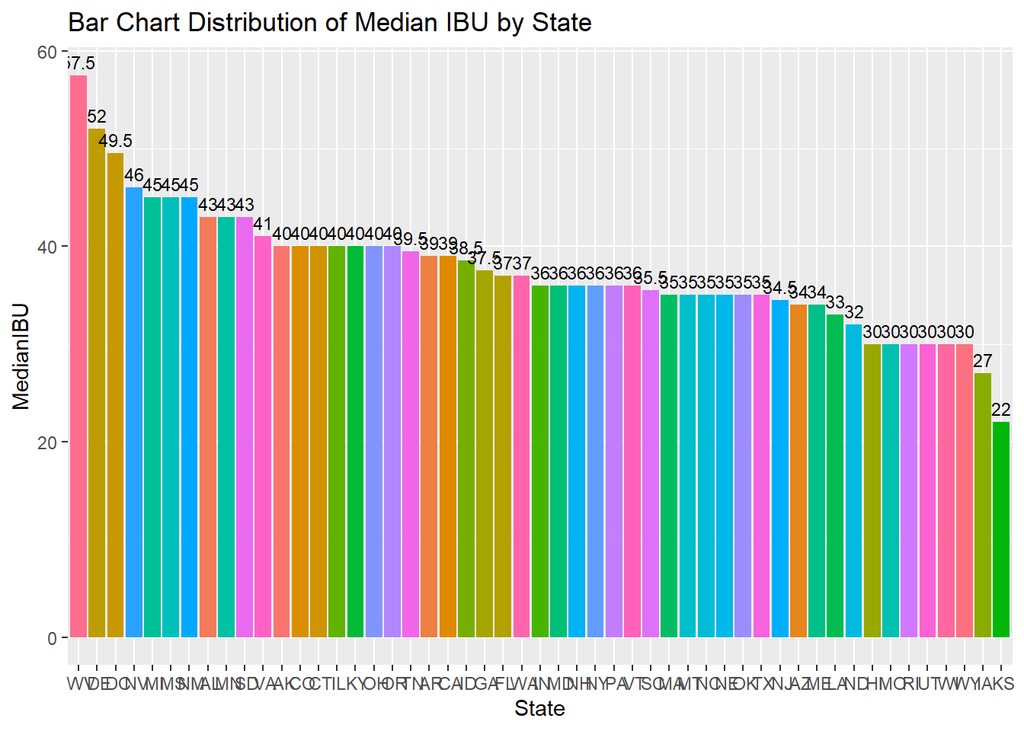

```r
#Create bar chart of median IBU for each State
beers_breweries %>%
  filter(!is.na(IBU))%>%
  group_by(State)%>%
  summarize(MedianIBU = median(IBU))%>%
  ggplot(aes(x=reorder(State,-MedianIBU), y = MedianIBU, fill=State))+
  geom_bar(stat="identity")+
  xlab("State")+
  ggtitle("Bar Chart Distribution of Median IBU by State") +
  guides(fill = FALSE) +
  geom_text(aes(label = MedianIBU), vjust = -0.5, size = 3)
```

## 5.

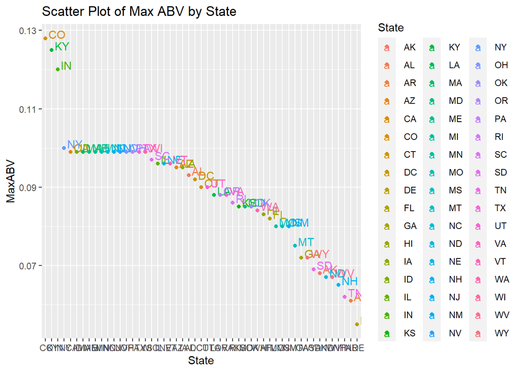

```r
#Scatter Plot to compute highest ABV
beers_breweries %>%
  filter(!is.na(ABV))%>%
  group_by(State)%>%
  summarize(MaxABV = max(ABV))%>%
  ggplot(aes(x=reorder(State,-MaxABV), y = MaxABV, color=State))+
  geom_text(aes(label=State),hjust=0, vjust=0)+
  geom_point()+
  xlab("State")+
  ggtitle("Scatter Plot of Max ABV by State")+
  theme_gray() +
  guides(fill = FALSE)
```

```r
  #using plotly to be able to hover over the plot
#p=beers_breweries %>%
#  filter(!is.na(ABV))%>%
#  group_by(State)%>%
#  summarize(MaxABV = max(ABV))%>%
#  ggplot(aes(x=reorder(State,-MaxABV), y = MaxABV, color=State))+
#  geom_text(aes(label=State),hjust=0, vjust=0)+
#  geom_point()+
#  xlab("State")+
#  ggtitle("Scatter Plot of Max ABV by State")+
#  theme_gray()
#ggplotly(p)

#What value is the MAX ABV for Colorado?
coloradodf = beers_breweries %>% filter(State == " CO")
coloradodf = coloradodf[order(coloradodf$ABV, decreasing=TRUE),]
head(coloradodf,1)
```

```
##                                                 BeerName Beer_ID   ABV IBU
## 224 Lee Hill Series Vol. 5 - Belgian Style Quadrupel Ale    2565 0.128 130
##     Brew_ID            Style Ounces             BreweryName    City State
## 224      52 Quadrupel (Quad)   19.2 Upslope Brewing Company Boulder    CO
```

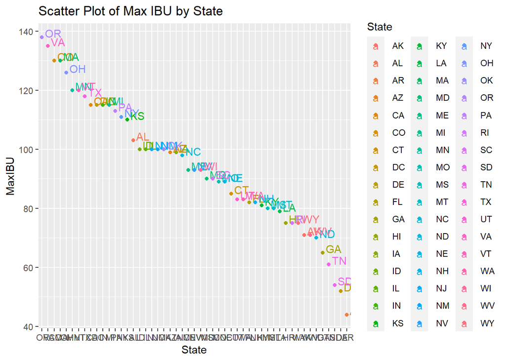

```r
#Scatter Plot to compute highest IBU
beers_breweries %>%
  filter(!is.na(IBU))%>%
  group_by(State)%>%
  summarize(MaxIBU = max(IBU))%>%
  ggplot(aes(x=reorder(State,-MaxIBU), y = MaxIBU, color=State))+
  geom_text(aes(label=State),hjust=0, vjust=0)+
  geom_point()+
  xlab("State")+
  ggtitle("Scatter Plot of Max IBU by State")+
  theme_gray() +
  guides(fill = FALSE)
```

```r
  #using plotly to be able to hover over the plot
#p=beers_breweries %>%
#  filter(!is.na(IBU))%>%
#  group_by(State)%>%
#  summarize(MaxIBU = max(IBU))%>%
#  ggplot(aes(x=reorder(State,-MaxIBU), y = MaxIBU, color=State))+
#  geom_text(aes(label=State),hjust=0, vjust=0)+
#  geom_point()+
#  xlab("State")+
#  ggtitle("Scatter Plot of Max IBU by State")+
#  theme_gray()
#ggplotly(p)

#What value is the MAX IBU for Oregon?
oregondf = beers_breweries %>% filter(State == " OR")
oregondf = oregondf[order(oregondf$IBU, decreasing=TRUE),]
head(oregondf,1)
```

```
##                     BeerName Beer_ID   ABV IBU Brew_ID
## 10 Bitter Bitch Imperial IPA     980 0.082 138     375
##                             Style Ounces             BreweryName    City State
## 10 American Double / Imperial IPA     12 Astoria Brewing Company Astoria    OR
```

## 6.

Comment on the summary statistics and distribution of the ABV variable. Answer - we have a right skewed distribution because the mean is greater than the median, meaning the outliers are likely to be far greater than the median.

```r
####summary(beers_breweries$ABV)
beers_breweries%>%
  filter(!is.na(ABV))%>%
  summarize(MeanABV = mean(ABV), SDABV = sd(ABV), MedianABV = median(ABV), MaxABV = max(ABV), MinABV = min(ABV), Q1 = quantile(ABV,0.25), Q3 = quantile(ABV,0.75), Range = max(ABV)-min(ABV), count = n())
```

```
##      MeanABV      SDABV MedianABV MaxABV MinABV   Q1    Q3 Range count
## 1 0.05977342 0.01354173     0.056  0.128  0.001 0.05 0.067 0.127  2348
```

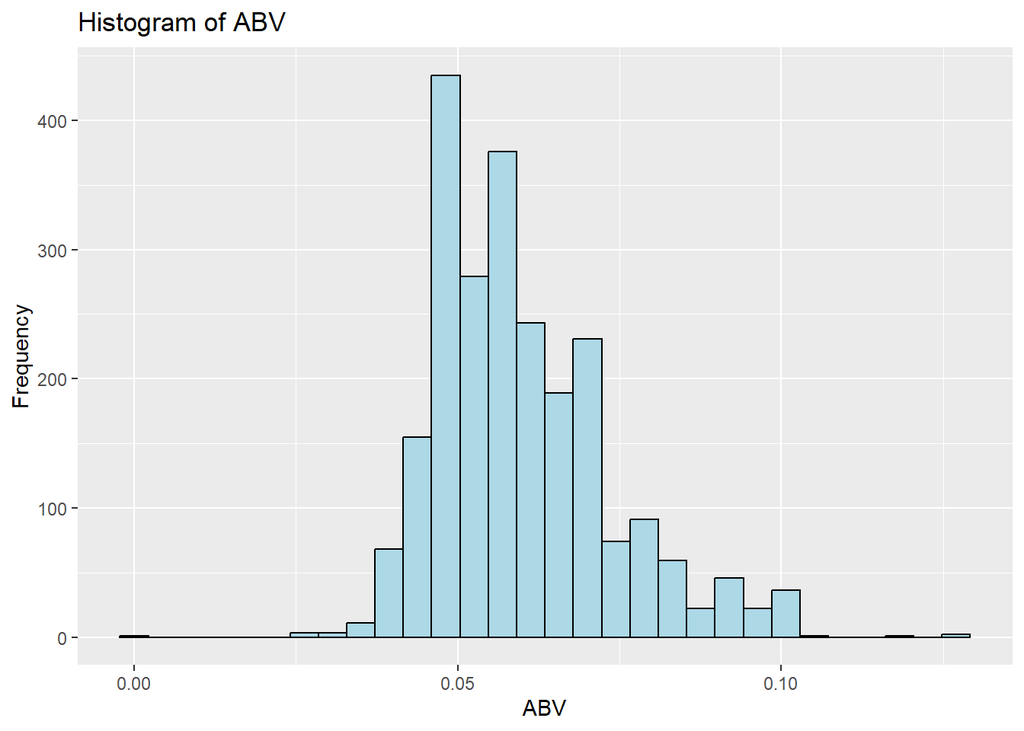

```r
ggplot(data = beers_breweries, aes(x = ABV)) +
  geom_histogram(bins = 30, fill = "lightblue", color = "black") +
  labs(title = "Histogram of ABV",
       x = "ABV",
       y = "Frequency")
```

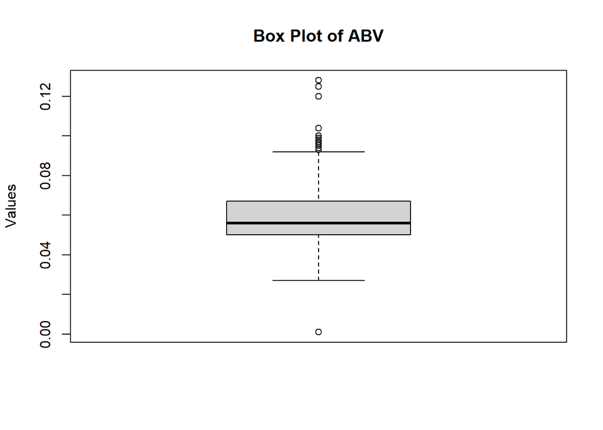

```r
boxplot(beers_breweries$ABV, main="Box Plot of ABV", ylab="Values")
```

## 7.

Is there an apparent relationship between the bitterness of the beer and its alcoholic content? Draw a scatter plot. Make your best judgment of a relationship and EXPLAIN your answer.

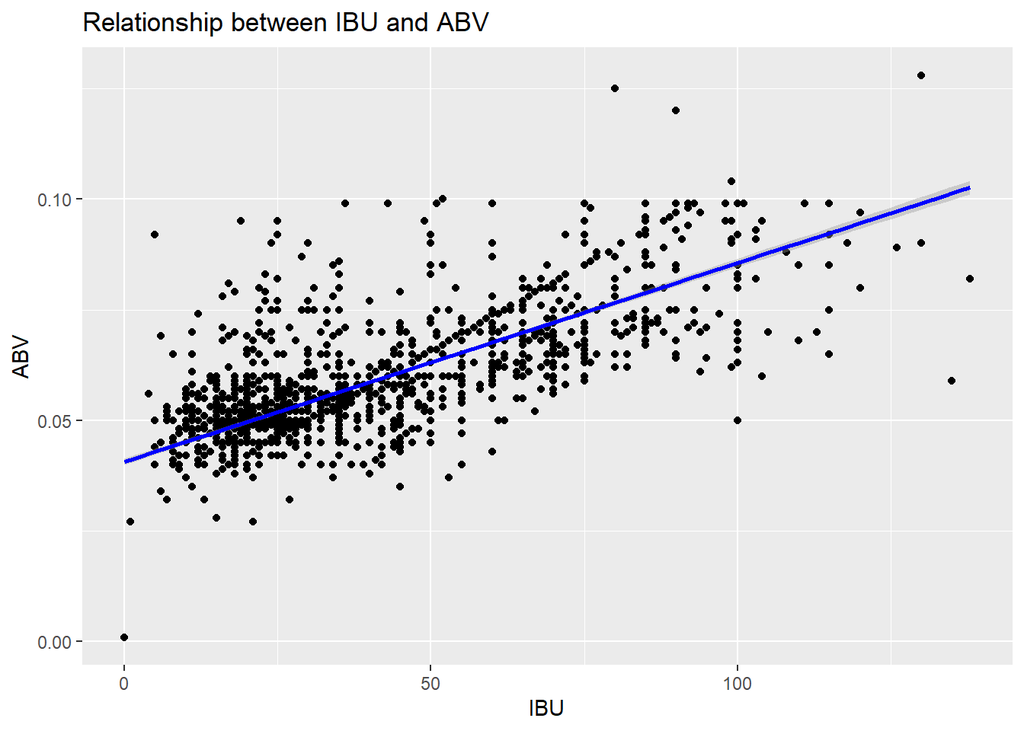

```r
#Question - Relationship between ABV and IBV(Bitterness)?
beers_breweries %>%
  filter(!is.na(ABV) & !is.na(IBU))%>%
  ggplot(aes(x=IBU, y=ABV))+
  geom_point()+
  geom_smooth(method="lm", col = "blue")+ #adding a blue linera regression line (lm) to the plot
  ggtitle("Relationship between IBU and ABV")
```

```r
# Correlation
beers_breweries_complete <- beers_breweries[complete.cases(beers_breweries),]
cor(x = beers_breweries_complete$ABV, y = beers_breweries_complete$IBU)
```

```
## [1] 0.7573115
```

## 8.

Budweiser would also like to investigate the difference with respect to IBU and ABV between IPAs (India Pale Ales) and other types of Ale (any beer with “Ale” in its name other than IPA). You decide to use KNN classification to investigate this relationship. Provide statistical evidence one way or the other. You can of course assume your audience is comfortable with percentages … KNN is very easy to understand conceptually. In addition, while you have decided to use KNN to investigate this relationship (KNN is required) you may also feel free to supplement your response to this question with any other methods or techniques you have learned. Creativity and alternative solutions are always encouraged.

KNN K = 5, 15 and Naive Bayes were used to help us better understand this relationship between IPA and other ales. 80.6% Accuracy with a Naïve Bayes Model 82.0% Accuracy relative to 5 nearest neighbors 80.0% Accuracy relative to 15 nearest neighbors

```r
#separating the Ales out of the data
ales = beers_breweries[grepl("\\bale\\b", beers_breweries$Style, ignore.case = TRUE) | grepl("\\bale\\b", beers_breweries$BeerName, ignore.case = TRUE) | grepl("ipa", beers_breweries$Style, ignore.case = TRUE) | grepl("ipa", beers_breweries$BeerName, ignore.case = TRUE),]


ales$IPA = grepl("IPA", ales$BeerName, ignore.case = TRUE) | grepl("IPA", ales$Style, ignore.case = TRUE)
ales$IPA = as.factor(ales$IPA)

#Iterating the model to explore the relationship between IPA and other ALES

#setting a variable for the count of iterations
iter = 100

#variables to hold the results
accnb = matrix(nrow = iter)
acck5 = matrix(nrow = iter)
acck15 = matrix(nrow = iter)
sensnb = matrix(nrow = iter)
sensk5 = matrix(nrow = iter)
sensk15 = matrix(nrow = iter)
specnb = matrix(nrow = iter)
speck5 = matrix(nrow = iter)
speck15 = matrix(nrow = iter)

for (s in 1:iter){
  #commenting out set seed first to see if I need to reset the seed each iteration
    set.seed(s)
    trainIndices = sample(seq(1:length(ales$ABV)),round(.7*length(ales$IBU)))
    trainAles = ales[trainIndices,]
    testAles = ales[-trainIndices,]


    #naive bayes with Test and Train Data
    #creating a naive bayes model to predict whether we have

    model = naiveBayes(trainAles[,c("ABV", "IBU")],trainAles$IPA,laplace = .1)
    #table(predict(model,testAles[,c("ABV", "IBU")],testAles$IPA, type = "raw"))
    CM = confusionMatrix(table(predict(model,testAles[,c("ABV", "IBU")]), testAles$IPA))
    accnb[s] = CM$overall[c("Accuracy")]
    sensnb[s] = CM$byClass[c("Sensitivity")]
    specnb[s] = CM$byClass[c("Specificity")]

    #KNN K = 5
    classifyAles = knn(trainAles[,c("IBU","ABV")], testAles[,c("IBU","ABV")], trainAles$IPA, prob = TRUE, k = 5)
    k5 = confusionMatrix(classifyAles, testAles$IPA)

    acck5[s] = k5$overall[c("Accuracy")]
    sensk5[s] = k5$byClass[c("Sensitivity")]
    speck5[s] = k5$byClass[c("Specificity")]

    #KNN K = 15
    classifyAles = knn(trainAles[,c("IBU","ABV")], testAles[,c("IBU","ABV")], trainAles$IPA, prob = TRUE, k = 15)
    k15 = confusionMatrix(classifyAles, testAles$IPA)
    acck15[s] = k15$overall[c("Accuracy")]
    sensk15[s] = k15$byClass[c("Sensitivity")]
    speck15[s] = k15$byClass[c("Specificity")]
}


#calculate mean accuracy
headers = c("Accuracy", "Sensitivity", "Specificity")
nb = c(colMeans(accnb), colMeans(sensnb), colMeans(specnb))
k5 = c(colMeans(acck5), colMeans(sensk5), colMeans(speck5))
k15 = c(colMeans(acck15), colMeans(sensk15), colMeans(speck15))

# Create the data frames
df_nb <- data.frame(NBCategory = headers, Values = nb)
df_k5 <- data.frame(K5Category = headers, Values = k5)
df_k15 <- data.frame(K15Category = headers, Values = k15)
df_nb
```

```
##    NBCategory    Values
## 1    Accuracy 0.8066311
## 2 Sensitivity 0.8701444
## 3 Specificity 0.6983503
```

```r
df_k5
```

```
##    K5Category    Values
## 1    Accuracy 0.8204478
## 2 Sensitivity 0.8660540
## 3 Specificity 0.7426493
```

```r
df_k15
```

```
##   K15Category    Values
## 1    Accuracy 0.7995949
## 2 Sensitivity 0.8448133
## 3 Specificity 0.7236145
```

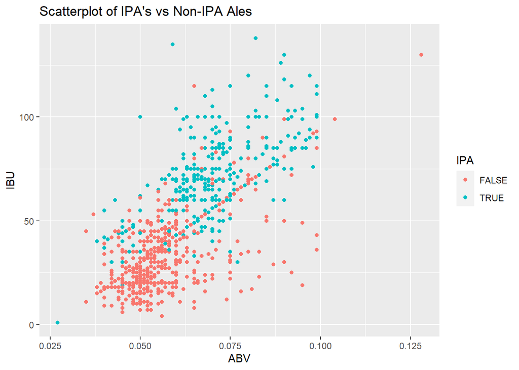

```r
#graphing IBU and ABV for Ales for IPA
ales %>% ggplot(aes(x = ABV, y = IBU, color = IPA))+ geom_point() + ggtitle("Scatterplot of IPA's vs Non-IPA Ales")
```

```r
#Distribution of style within TX, CA, CO. Choosing 3 with many breweries to test through KNN and NB

TexasBB = beers_breweries %>% filter(str_trim(State) == "TX")
CaliforniaBB = beers_breweries %>% filter(str_trim(State) == "CA")
ColoradoBB = beers_breweries %>% filter(str_trim(State) == "CO")
summary(beers_breweries$State)
```

```
##  AK  AL  AR  AZ  CA  CO  CT  DC  DE  FL  GA  HI  IA  ID  IL  IN  KS  KY  LA  MA
##  25  10   5  44 182 250  27   8   1  56  16  27  30  30  91 137  23  20  19  82
##  MD  ME  MI  MN  MO  MS  MT  NC  ND  NE  NH  NJ  NM  NV  NY  OH  OK  OR  PA  RI
##  21  27 151  55  39  11  39  55   3  21   8   8  13  10  73  49  19 125  97  27
##  SC  SD  TN  TX  UT  VA  VT  WA  WI  WV  WY
##  14   7   6 124  26  40  27  68  85   2  15
```

```r
#adding columns in BB for TX, CA, CO, SD and not each of those states
beers_breweries = beers_breweries %>% mutate(TX = ifelse(grepl("TX", str_trim(State), ignore.case = TRUE), "Y", "N")) %>% mutate(TX = factor(TX, levels = c("Y", "N")))

beers_breweries = beers_breweries %>% mutate(CA = ifelse(grepl("CA", str_trim(State), ignore.case = TRUE), "Y", "N")) %>% mutate(CA = factor(CA, levels = c("Y", "N")))

beers_breweries = beers_breweries %>% mutate(CO = ifelse(grepl("CO", str_trim(State), ignore.case = TRUE), "Y", "N")) %>% mutate(CO = factor(CO, levels = c("Y", "N")))

beers_breweries = beers_breweries %>% mutate(SD = ifelse(grepl("SD", str_trim(State), ignore.case = TRUE), "Y", "N")) %>% mutate(SD = factor(SD, levels = c("Y", "N")))


beers_breweries
```

[output not shown]

[output cut: 7032 more lines]

9. Knock their socks off! Find one other useful inference from the data that you feel Budweiser may be able to find value in. You must convince them why it is important and back up your conviction with appropriate statistical evidence.

By using KNN K = 3 we explored which beers are most likely to be mistaken for beer belonging to another State. The False positives in this analysis could help identify market opportunities to move products between states to help gain more market share.

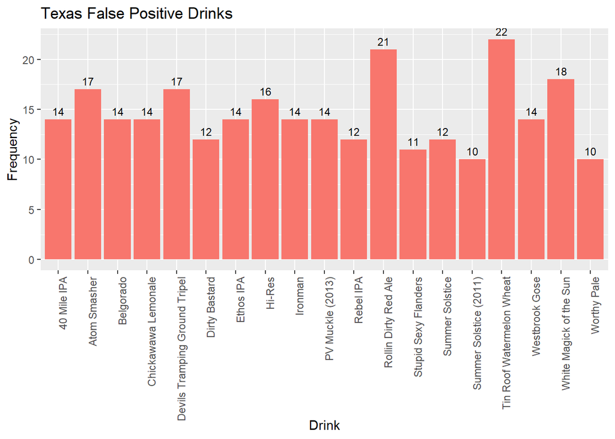

```r
#9 KNN and NB to see whether predict whether drinks are similar to ones in other markets

#trimming State in BB dataset
beers_breweries$State = str_trim(beers_breweries$State)
beers_breweries$BeerName = as.character(beers_breweries$BeerName)
#setting a variable for the count of iterations
iter = 100

#variables to hold the results
TXFP = list()
CAFP = list()
COFP = list()
SDFP = list()

#iterate through 100 iterations
for (s in 1:iter) {
  set.seed(s)
  trainIndices = sample(seq(1:length(beers_breweries$ABV)), round(0.7 * length(beers_breweries$IBU)))
  trainStates = beers_breweries[trainIndices,]
  testStates = beers_breweries[-trainIndices,]

  # KNN K = 3
  classifyStates = knn(trainStates[, c("IBU", "ABV")], testStates[, c("IBU", "ABV")], trainStates$TX, prob = TRUE, k = 3)
  kTX = confusionMatrix(classifyStates, testStates$TX)

  #captures indices of Y in the model table and the test set
  L1 = grep("Y", classifyStates)
  L2 = grep("Y", testStates$TX)
  # Create a list of indices in L1 that are not in L2
  FP = list(setdiff(L1, L2))

  #save False Positives to TXFP
  for (i in FP) {
  TXFP[[s]] = (testStates$BeerName[i])
  }

  #KNN for CA Data
  classifyStates = knn(trainStates[, c("IBU", "ABV")], testStates[, c("IBU", "ABV")], trainStates$CA, prob = TRUE, k = 3)
  kCA = confusionMatrix(classifyStates, testStates$CA)

  #captures indices of Y in the model table and the test set
  L1 = grep("Y", classifyStates)
  L2 = grep("Y", testStates$CA)
  # Create a list of indices in L1 that are not in L2
  FP = list(setdiff(L1, L2))

  #save False Positives to CAFP
  for (i in FP) {
  CAFP[[s]] = (testStates$BeerName[i])
    }

  #KNN for CO data
  classifyStates = knn(trainStates[, c("IBU", "ABV")], testStates[, c("IBU", "ABV")], trainStates$CO, prob = TRUE, k = 3)
  kCO = confusionMatrix(classifyStates, testStates$CO)

  #captures indices of Y in the model table and the test set
  L1 = grep("Y", classifyStates)
  L2 = grep("Y", testStates$CO)
  # Create a list of indices in L1 that are not in L2
  FP = list(setdiff(L1, L2))

  #save False Positives to COFP
  for (i in FP) {
  COFP[[s]] = (testStates$BeerName[i])
    }

}

#List out the false positives into a data frame
TXFP = unlist(TXFP)
TXTable = as.data.frame(table(TXFP))
TXTableR = TXTable %>% filter(Freq >= 10)

#List out the false positives into a data frame
CAFP = unlist(CAFP)
CATable = as.data.frame(table(CAFP))
CATableR = CATable %>% filter(Freq >= 10)

#List out the false positives into a data frame
COFP = unlist(COFP)
COTable = as.data.frame(table(COFP))
COTableR = COTable %>% filter(Freq >= 10)

TXTableR %>% ggplot(aes(x = TXFP, y = Freq, fill = "orange")) + geom_bar(stat = "identity") + ggtitle("Texas False Positive Drinks") + xlab("Drink") + ylab("Frequency") + theme(axis.text.x = element_text(angle = 90, hjust = 1)) + guides(fill = FALSE) + geom_text(aes(label = Freq), vjust = -0.5, size = 3)
```

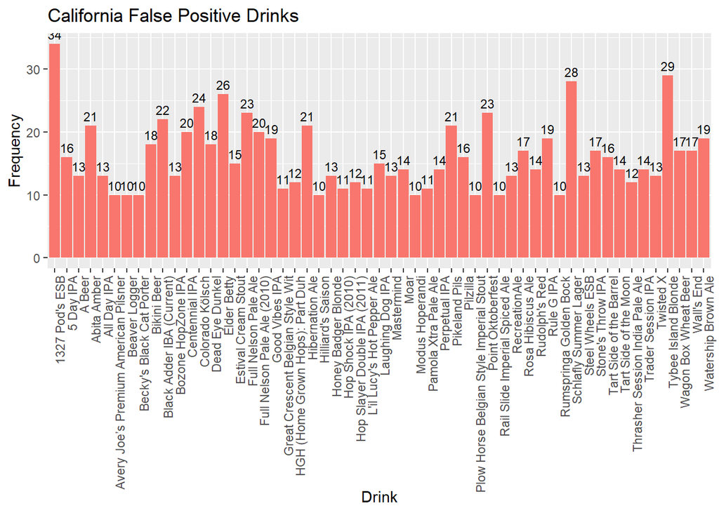

```r
CATableR %>% ggplot(aes(x = CAFP, y = Freq, fill = "orange")) + geom_bar(stat = "identity") + ggtitle("California False Positive Drinks") + xlab("Drink") + ylab("Frequency") + theme(axis.text.x = element_text(angle = 90, hjust = 1)) + guides(fill = FALSE) + geom_text(aes(label = Freq), vjust = -0.5, size = 3)
```

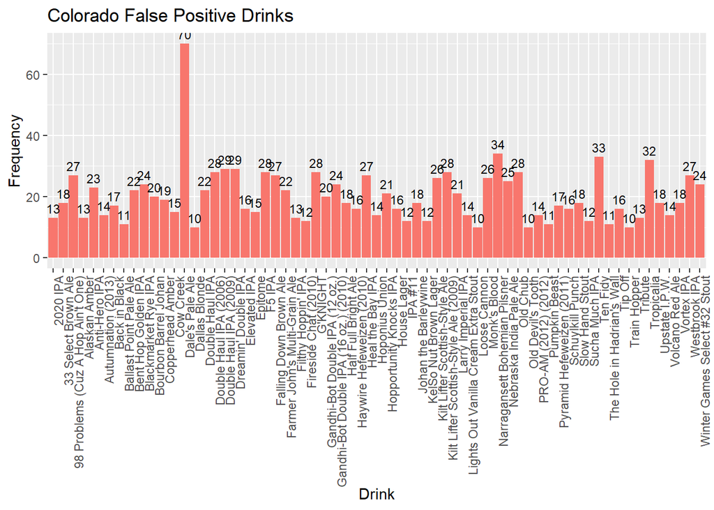

```r
COTableR %>% ggplot(aes(x = COFP, y = Freq, fill = "orange")) + geom_bar(stat = "identity") + ggtitle("Colorado False Positive Drinks") + xlab("Drink") + ylab("Frequency") + theme(axis.text.x = element_text(angle = 90, hjust = 1)) + guides(fill = FALSE) + geom_text(aes(label = Freq), vjust = -0.5, size = 3)
```